# The Network Gap

The Gender Gap in Professional Networking

Charlotte McCulloh

#### charlotte.mcculloh@duke.edu

11/21/2020

## Introduction

In today’s culture of mass online job applications, getting hired is no easy process. Forming professional connections has become an increasingly vital step to navigating the job market and is, in many ways, just as important as the skills on your resume. Professional networking is a means of gaining industry knowledge, learning about job and promotional opportunities, and forming relationships with people who might be able to provide recommendations in the future. Therefore, having the right contacts and timely access to information can mean the difference between getting hired or passed by recruiters. One of the most challenging issues that aspiring workers face today is learning how to network effectively, and it continues to be an issue throughout their career when being considered for promotions or changing organizations.

It is our responsibility, then, to also learn about biases that exist within professional networking. It is no secret that women have to face many hurdles as job applicants and within the workplace that men do not, and networking is not immune to this gender bias. We know that men are more likely to achieve leadership and high-paying positions, and since their education or skills do not necessarily differ from that of their female counterparts, the difference between their professional networks could potentially explain some of the gender disparity in management roles. Do psychological differences between the genders mean that it is more difficult for women to build networks, or is it external factors that hinder women’s ability to network effectively?

This study aims to explore the differences between the structure of male and female professional networks with the hope that highlighting these dissimilarities will allow for a better understanding of some of the major issues within modern job markets and how women can network more effectively going forward.

### Definition of Terms

- *Professional networking* - the building and maintaining of relationships with people within your professional industry
- *Internal networking* - networking with people within your own organization
- *External networking* - networking with people outside of your organization
- *Betweenness centrality* - a measure of the most important nodes in a network based on the shortest path between that node and the others
- *Openness* - a measure of a social network based on the number of connections linked to an individual that are not also directly linked to each other

## Background

Literature proves that there are many benefits to professional networking, including access to technical knowledge, emotional support, advice, and strategic insight (Greguletz et. al. 2). Studies have also found that those who actively develop their professional network are more likely to use sites such as Linkedin and Xing, especially when trying to create external networking ties. It is generally argued that, while social networking sites such as Facebook and Twitter are used to maintain existing relationships, professional networking sites such as Linkedin and Xing are used for extending networks, and networks on these often involve far more latent connections than on social networking sites (Utz et. al 4). In fact, on Linkedin, the number of connections a person has, even if the user claims they were primarily weak connections, is a significant predictor of their access to informational benefits such as access to resources and career opportunities (Utz et. al. 3). A person’s network is indeed a valuable asset, and professional networking sites show a great deal of the strength of these networks and the overall networking aptitude of their users.

At the beginning of this year, Linkedin conducted a study that analyzed over 675 million user accounts from over two hundred countries. Taking into account the overall size as well as openness of a users’ network, they were able to create a measure of network strength and labeled a user as one with a “strong network” if their network strength was within the eightieth percentile (Lewis). What they found identified a massive problem in modern professional networking. Out of people who identified as either male or female on their Linkedin profile, women in the United States were 28% less likely to have a strong network than males (Lewis). In fact, in every country they surveyed, women were consistently between 14 and 38% behind. Linkedin labels this as “the network gap,” and claims to, as a company, be working to close the said gap through publically available networking courses and encouraging companies to avoid language in their job descriptions that may imply bias towards one gender. These are some of many steps that could be taken to attempt to mend the gender gap by teaching women how to improve their networking skills, but these efforts do not target the root of the issue. After all, why do females have weaker networks in the first place?

A worldwide phenomenon such as this simply cannot be explained by a lack of knowledge. In 2018, Elena Greguletz, business consultant and former researcher for Engineers Without Borders, conducted a study with her team that proposed a few potential explanations. They interviewed 37 female business leaders of various German corporations in an attempt to uncover the behaviors that differentiated women and men when developing their professional networks (Greguletz et. al. 1). They determined that both structural exclusion and personal hesitation pose significant disadvantages. Females face structural exclusion in the sense that evening and weekend networking events conflicted with the schedules of women trying to raise children, an issue that was mentioned by many of the interviewees (Greguletz et. al. 14). Greguletz and her time also suggest that women simply have less confidence to network as men would because people prefer to interact with people like themselves, so women are more reluctant to try to form a professional relationship with a man and thus interact with more females. In addition, females tend to feel morally obligated to help lower-level employees through support and mentorship, which means that they have less interaction with superiors (Greguletz et. al. 16). These and many other theories of theirs suggest that it is a mixture of structural sexism and their own psychology that hinder a woman’s ability to network.

However, while many studies claim that women have weaker professional networks than men, their definition of a strong network is subjective. Linkedin’s study of network strength is not the only statistic worth studying. The fact is that men and women tend to form different kinds of networks and thus may require divergent definitions of network strength. The Harvard Business Review claims that, while both men and women benefit from being central within a network, women also require an inner circle of female contacts in order to achieve executive positions (Uzzi). The author explains that, although centrality provides access to informational benefits, women seeking leadership roles often face political challenges as a result of their gender, and close female contacts allow them to also share inside information about an organization’s attitude towards women (Uzzi). Knowing this can help a woman find the right job, better prepare for interviews, and understand how to negotiate their hiring terms. Women in the top quartile of centrality who also had an inner circle of close female contacts have a salary 2.5 times higher on average than females lacking the combination (Uzzi). While men also have contacts within their circles that they are closer to than others, the gender composition of those close contacts does not correlate to better job placement as it does with women. Women that have a high centrality without an inner circle, resembling a man’s typical network, usually have low-ranking jobs with smaller pay (Uzzi).

Even within this inner circle of females, openness continues to be important. The most effective female circles were those with few other contacts in common (Uzzi). Those that were too interconnected failed to generate any useful information for each other, emphasizing the importance of diverse relationships. The study done by Linkedin measured the size and openness of both men and women’s networks but did not account for any inner circles or differences between close and weak contacts. This leaves three essential measurements of a professional network to consider: size, centrality, and openness, and it is unclear how exactly they work together to indicate network strength or whether Linkedin’s initial claim that women have weaker networks is indeed accurate.

## Hypotheses

**Hypothesis 1: Men tend to have a larger professional network than women**

Online professional networks are built through contacts people know on a close personal basis as well as those that they meet at networking events. Based on the conclusion that women have a more difficult time attending and making use of networking events, I believe that this will lead to them having a smaller online presence. The number of connections tied to a professional media account is a reflection of how well the user is able to attain weak ties, and a larger network should result in greater access to industry information through shared news feeds, so having a smaller professional network could put a woman at a significant disadvantage, even if nothing else about the network is known.

However, following someone on social media does not indicate a strong or genuine relationship. The number of online professional connections exposes nothing about the quality or structure of a person’s professional network. This leads to another hypotheses:

**Hypothesis 2: Men tend to be a more central contact in professional networks than women do**

Finally, I expect to find that men tend to have a higher centrality within their professional network, as indicated by previous research. According to many social scientists, this is the primary reason that they are considered to have stronger and more effective professional networks.

**Hypothesis 3: The correlation between women’s online network size and her attractiveness if stronger than that between a man’s online network size and his**

Some of the more interesting data that I was able to collect rated people’s attractiveness on their Linkedin profile picture. I want to test whether a user’s perceived appearance on their professional networking account is correlated to their ability to establish an online professional network. More importantly, I want to see if this is a more significant factor for women than it is for men. Women face plenty of gender bias within the workplace as it is, and this could be one of the biases contributing to differences in online social networking performance. Professional networking online is remarkably similar to online social networking, so I predict that women will be judged more harshly on their appearance as they are believed to be on other social media platforms.

## Methods

#### Data Collection

Unfortunately, professional networking data is not so easily accessible. Most professional networking sites will ask for payment or certain qualifications to access the privileges necessary to attain information for this type of study, while others simply will not release information about a user’s profile for the purposes of research. However, I was able to find a pre-made dataset of Linkedin profile information from Kaggle, dating back to 2017. The dataset contains basic information from over 15,000 Linkedin user accounts, primarily those found in Australia (Truman). While it does not contain information about the identity of the users’ connections or whether there are any mutual ties between different accounts, making it impossible to pull data for nodes and edges for network analysis, it does contain plenty of interesting demographic information about the user, as well as their total number of followers. This allows us to compare the overall size of Linkedin users’ professional network based on gender or other demographic factors.

However, the number of online professional connections exposes nothing about the structure of a person’s professional network. For that, I used a separate dataset of Linkedin profiles from 2015 that did have all of the information to perform network analysis. Unlike the one found on Kaggle, it does not contain any demographic information, only the user’s identifier and connections to other users in the dataset. The files are set up with one representing the nodes of the network and the other the edges. I determined the user’s gender through an algorithm and hence it is only guessed, not known for certain.

#### Data Analysis

**Hypothesis 1** The data from Kaggle was first cleaned by eliminating irrelevant columns from the data frame. Then, I removed all users with 0 followers, since these were accounts that were either unused or not used to build the user’s professional network. Even then, the data contained a few outliers with regards to the number of followers. This means that the median, which is resistant to outliers, will be the best measure of the data’s center. To compare the median number of followers for males and that of females, I did a Mood’s median test using the RVAideMemoire package in R. This will show the difference in size, thereby testing my first hypothesis.

**Hypothesis 2** My second hypothesis used the Linkedin networking data. This consisted of 3,625,091 users total, but I reduced it to 11,000 for convenience. All 11,000 were processed through the r gender package, available on github, which gives a prediction of gender based on a user’s first name (fangzhou-xie). All users that had a probability over 0.7 of being male or female were labeled as such, while those that did not have a strong liklihood of being either were removed from the dataset. Since the Linkedin data was not always set up to make the user’s name easily accessible, this left only 6686 users to work with: 2396 male and 4290 female. From here, I created a network graph from the data frame and calculated the centrality of the female and male nodes.

**Hypothesis 3** My third hypothesis again used the data from Kaggle. I person’s “beauty” rating was given as a number between 0 and 100, so a simple linear regression analysis was able to determine the correlation between the attractiveness of a user’s profile picture and the size of their Linkedin network. Again, this is excluding users who had no Linkedin connections.

## Results

**Hypothesis 1** A visualization of the median number of Linkedin followers by gender can be seen through a box plot:

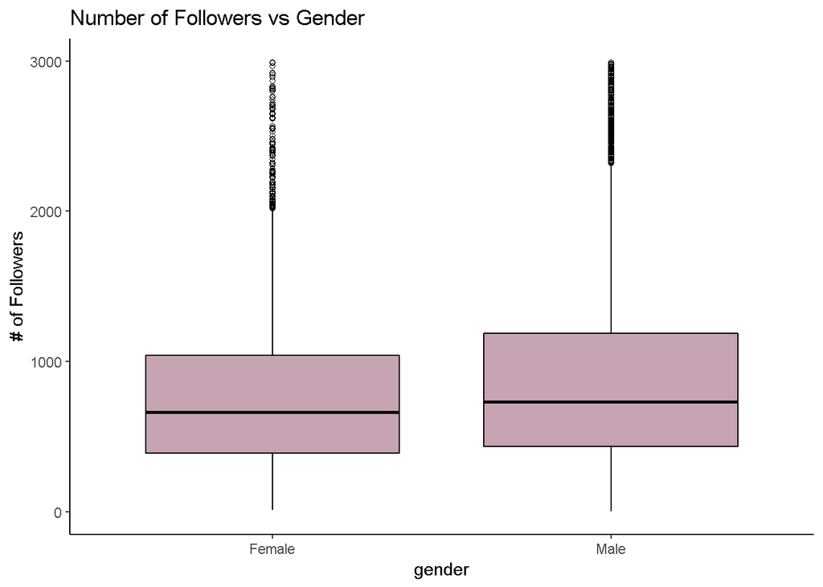

For the convenience of viewing, the plot is cut off at 3000 followers, but there are other outliers that exist above the upper quartile. As the plot shows, the spread of number of followers in male and female’s Linkedin networks is not drastically different. Males have a slightly larger spread, and, as predicted, they have a higher median. The median number of followers for men is 770 while it is 698 for females. While a difference of 72 is not that much, the results of the Mood’s median test, with had a p-value less than 2.2e-16, suggest that the population medians are likely unequal at any reasonable confidence level.

**Hypothesis 2**

Network analysis of the second set of Linkedin data shows that there is a significant difference between the mean centrality of males and that of females, and it is opposite of my prediction. In this particular Linkedin network, females appear to be far more central than males, with a mean centrality of 57.89278, while males have a mean centrality of only 17.21535.

**Hypothesis 3** The results of the regression analysis of the size of a user’s Linkedin network and their attractiveness is below. As seen in the graphs, most of the ratings for beauty fall within the middle of the 0-100 range.

```
##
## Call:
## lm(formula = n_followers ~ beauty, data = men)
##
## Residuals:
##    Min     1Q Median     3Q    Max
##  -1324   -855   -536     13 529248
##
## Coefficients:
##             Estimate Std. Error t value Pr(>|t|)
## (Intercept) 1455.852    163.380   8.911   <2e-16 ***
## beauty        -2.549      2.810  -0.907    0.364
## ---
## Signif. codes:  0 '***' 0.001 '**' 0.01 '*' 0.05 '.' 0.1 ' ' 1
##
## Residual standard error: 7091 on 45925 degrees of freedom
## Multiple R-squared:  1.791e-05,  Adjusted R-squared:  -3.864e-06
## F-statistic: 0.8225 on 1 and 45925 DF,  p-value: 0.3644
```

```
##
## Call:
## lm(formula = n_followers ~ beauty, data = women)
##
## Residuals:
##    Min     1Q Median     3Q    Max
##  -1299   -753   -463    -17 192448
##
## Coefficients:
##             Estimate Std. Error t value Pr(>|t|)
## (Intercept)  785.202    182.741   4.297 1.74e-05 ***
## beauty         6.421      3.053   2.103   0.0354 *
## ---
## Signif. codes:  0 '***' 0.001 '**' 0.01 '*' 0.05 '.' 0.1 ' ' 1
##
## Residual standard error: 4259 on 14343 degrees of freedom
## Multiple R-squared:  0.0003084,  Adjusted R-squared:  0.0002387
## F-statistic: 4.425 on 1 and 14343 DF,  p-value: 0.03544
```

[figure not shown]

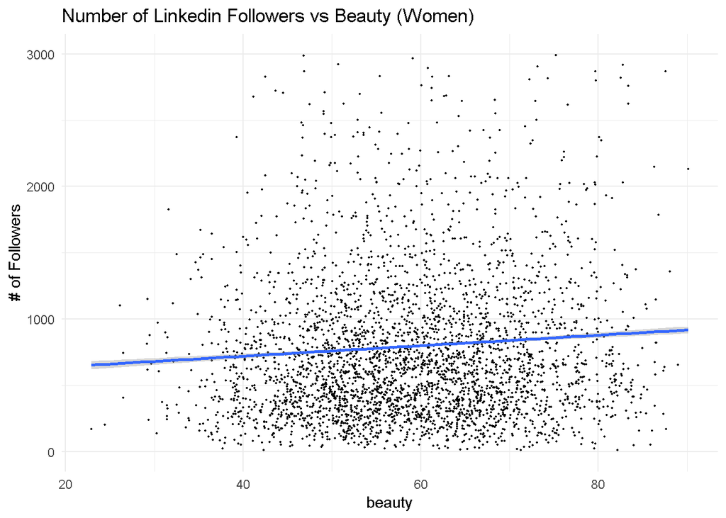

## Conclusions

However, the most surprising find was that women actually had a much higher centrality than men within the Linkedin dataset. This directly contradicts the findings of The Harvard Business Review, which claimed that men more often had a higher centrality within their networks. Since my study is fairly limited, with only one dataset being used to test each hypothesis, I cannot generalize my findings to say that this pattern would persist in most Linkedin networks, but I believe it warrants more research to be done on the subject.

Even with access to hundreds of online recruitment sites, finding a job that best suits one’s interests and qualifications is still one of the most difficult challenges that people face, and making themselves stand out to recruiters is more difficult still. Professional networking has become increasingly important for a successful career, but, for some, it is easier than others.

Women face countless challenges in the workplace, and networking is only one of them. In 2017, Shiliang Tang of UC Santa Barbara and his team tested one possible explanation. They were able to develop an algorithm to detect and rate gender bias in job descriptions, and, through analyzing over 17 million Linkedin job postings from the previous decade, determined that there was bias both in the language of job listings as well as in the people that applied for them (Shiliang 2). The fact is that women have to approach the professional world differently than men do, so there will of course be variations in how they approach professional networking.

## Future Work

The results of this study show that men and women indeed form professional networks differently from one another. As to how exactly they form them and how effective their approaches are, more research has yet to be done.

These questions are particularly difficult to answer because we do not know for sure what makes a network effective in the first place. Men and women benefit from professional networking in different ways, so there is no singular or clear definition of what makes a “strong” professional network. The only idea that we have to measure by is observing the patters of women that have successfully attained leadership positions in their industries, but even finding people who fit this description is a challenge.

One metric that was not tested in this study was the openness of a professional network. Analyzing this requires data that is either much broader than used in this study or is limited to a select group of people. It would have to be done using an online dataset of people within the same industry and organization, as Linkedin has already done (Lewis). However, the Linkedin researchers used only this metric and the size of the network to determine the strength of the network. It would be better to have utilized their dataset to also take into account centrality. Linkedin should have also made an effort to recognize the differences between men and women’s networking and defined a “strong” network based on factors specific to each gender. For instance, as the study published in *The Harvard Business Review* found, women have a much stronger network if they have a small inner circle of female contacts, whereas this was unimportant for men. This would be an important consideration when trying to measure the strength and effectiveness of an individual network.

Another part of professional networking that I wished I had been able to analyze was comparing strong and weak relationships. Based on some of the conclusions of studies that analyzed women’s networking patterns, I theorize that women tend to form closer relationships with people within their organization (are better at internal networking). The analysis of Linkedin data that I was able to accomplish pertains primarily to weak ties, since that is how the website is generally designed. My ideal research design would be to analyze the social network of men and women on Facebook and look at their connections with people who work at their same organization. Facebook profiles contain both information about gender and workplace, but the Facebook API does not allow researchers to pull this type of personal information. I spent a lot of time during this research process attempting to do a similar analysis with Twitter data, but, since Twitter does not track profession or workplace, it was difficult to narrow my search to relevant networks. I tried to map the networks of people who followed pages such as attJOBS and WeAreCisco, which appear to be tailored to exchanging information between their company employees, but, after a lot of time, I unfortunately found that these networks were not as interconnected as I had hoped and showed few to no relationships between the users. I believe that a study on Facebook or similar data would yield far more statistically significant and interesting results.

There is a lot more that researchers can do to better understand professional networking, and it is our responsibility to continue addressing these issues if we ever hope to minimize the gender gap.

## References

#### Data

1. Ahmed, Nesreen K. Rossi, Ryan A. “The Network Data Repository with Interactive Graph Analytics and Visualization.” *Network Repository*, 2015. http://networkrepository.com/soc-twitter.php.
2. fangzhou-xie. “Gender.” *ropensci*, 2020. https://github.com/ropensci/gender.
3. Truman, Andrew. “LinkedIn Profile Data.” Kaggle, 2 Jan. 2018, www.kaggle.com/killbot/linkedin.

#### Other Readings

1. Greguletz, Elena, et al. “Why Women Build Less Effective Networks than Men: The Role of Structural Exclusion and Personal Hesitation.” Human Relations, vol. 72, no. 7, July 2019, pp. 1234–1261, doi:10.1177/0018726718804303.
2. Lewis, Gregory. “LinkedIn Data Shows Women Are Less Likely to Have Strong Networks - Here’s What Companies Should Do.” LinkedIn Talent Blog, Mar. 2020, business.linkedin.com/talent-solutions/blog/diversity/2020/women-less-likely-to-have-strong-networks.
3. Shiliang Tang, Xinyi Zhang, Jenna Cryan, Miriam J. Metzger, Haitao Zheng, and Ben Y. Zhao. 2017. “Gender Bias in the Job Market: A Longitudinal Analysis.” Proc. ACM Hum.-Comput. Interact. 1, 2, Article 99 (November 2017).
4. Utz, Sonja, and Johannes Breuer. “The Relationship Between Networking, LinkedIn Use, and Retrieving Informational Benefits.” Cyberpsychology, Behavior and Social Networking, Mary Ann Liebert, Inc., Publishers, Mar. 2019, www.ncbi.nlm.nih.gov/pmc/articles/PMC6444899/.
5. Uzzi, Brian. Research: Men and Women Need Different Kinds of Networks to Succeed. Harvard Business Review, 25 Feb. 2019, hbr.org/2019/02/research-men-and-women-need-different-kinds-of-networks-to-succeed.